# 0. Importing Packages

```python
import numpy as np
import pandas as pd
pd.set_option('display.max_columns', None)
from datetime import timedelta
import isodate
```

```python
#data visualisation
import matplotlib.pyplot as plt
import seaborn as sns
import plotly.express as px
import plotly.io as pio
pio.renderers.default = 'jupyterlab'
```

```python
#summary tools for enhanced EDA
!pip install summarytools
from summarytools import dfSummary

#ignore warnings
import warnings
warnings.simplefilter(action='ignore', category = FutureWarning)
```

# 1. Load Dataset

```python
df = pd.read_csv('E:/OneDrive - UTS/Sem 4 (Spring 2024)/Advanced ML Applications/Assignment 3/adv_mla_at3/data/raw/df_airport.csv', low_memory=False)
```

# 2. Data Exploration and Transformation

```python
df.head()
```

|  | legId | searchDate | flightDate | startingAirport | destinationAirport | travelDuration | isBasicEconomy | isRefundable | isNonStop | totalFare | totalTravelDistance | segmentsDepartureTimeEpochSeconds | segmentsDepartureTimeRaw | segmentsArrivalTimeEpochSeconds | segmentsArrivalTimeRaw | segmentsArrivalAirportCode | segmentsDepartureAirportCode | segmentsAirlineName | segmentsAirlineCode | segmentsEquipmentDescription | segmentsDurationInSeconds | segmentsDistance | segmentsCabinCode |
| --- | --- | --- | --- | --- | --- | --- | --- | --- | --- | --- | --- | --- | --- | --- | --- | --- | --- | --- | --- | --- | --- | --- | --- |
| 0 | 90be63bfc2848acb3a0d9a6c588b1f7d | 2022-04-16 | 2022-04-17 | OAK | ATL | PT6H32M | False | False | False | 307.60 | 2175.0 | 1650228600\|\|1650239400 | 2022-04-17T13:50:00.000-07:00\|\|2022-04-17T17:5... | 1650234660\|\|1650252120 | 2022-04-17T16:31:00.000-06:00\|\|2022-04-17T23:2... | SLC\|\|ATL | OAK\|\|SLC | Delta\|\|Delta | DL\|\|DL | \|\|Airbus A321 | 6060\|\|12720 | 588\|\|1587 | coach\|\|coach |
| 1 | 2a6f46df8129bcab9b7fe6825b2e9431 | 2022-04-16 | 2022-04-17 | OAK | ATL | PT7H38M | False | False | False | 387.60 | 2281.0 | 1650204600\|\|1650216900 | 2022-04-17T07:10:00.000-07:00\|\|2022-04-17T10:3... | 1650209700\|\|1650232080 | 2022-04-17T08:35:00.000-07:00\|\|2022-04-17T17:4... | LAX\|\|ATL | OAK\|\|LAX | Delta\|\|Delta | DL\|\|DL | Embraer 175 (Enhanced Winglets)\|\|Airbus A321 | 5100\|\|15180 | 338\|\|1943 | coach\|\|coach |
| 2 | 7bbf383c6e0433cfa4981efa7e5f459e | 2022-04-16 | 2022-04-17 | OAK | ATL | PT8H45M | True | False | False | 387.60 | 2850.0 | 1650202200\|\|1650216600 | 2022-04-17T06:30:00.000-07:00\|\|2022-04-17T10:3... | 1650209700\|\|1650233700 | 2022-04-17T08:35:00.000-07:00\|\|2022-04-17T18:1... | SEA\|\|ATL | OAK\|\|SEA | Alaska Airlines\|\|Alaska Airlines | AS\|\|AS | Airbus A320\|\|Boeing 737-900 | 7500\|\|17100 | 672\|\|2178 | coach\|\|coach |
| 3 | beb2015506ff7697a4af6af599bb07ff | 2022-04-16 | 2022-04-17 | OAK | ATL | PT14H17M | False | False | False | 451.58 | NaN | 1650204600\|\|1650241200 | 2022-04-17T07:10:00.000-07:00\|\|2022-04-17T17:2... | 1650209640\|\|1650256020 | 2022-04-17T08:34:00.000-07:00\|\|2022-04-18T00:2... | LAX\|\|ATL | OAK\|\|LAX | Spirit Airlines\|\|Spirit Airlines | NK\|\|NK | \|\|AIRBUS INDUSTRIE A320 SHARKLETS | 5040\|\|14820 | None\|\|None | coach\|\|coach |
| 4 | c5bfe3fb92bb262b94628a930fa30cef | 2022-04-16 | 2022-04-17 | OAK | ATL | PT9H6M | False | False | False | 463.58 | NaN | 1650239100\|\|1650258600 | 2022-04-17T16:45:00.000-07:00\|\|2022-04-17T22:1... | 1650244200\|\|1650271860 | 2022-04-17T18:10:00.000-07:00\|\|2022-04-18T04:5... | LAS\|\|ATL | OAK\|\|LAS | Spirit Airlines\|\|Spirit Airlines | NK\|\|NK | \|\|AIRBUS INDUSTRIE A320 SHARKLETS | 5100\|\|13260 | None\|\|None | coach\|\|coach |

```python
df.tail()
```

|  | legId | searchDate | flightDate | startingAirport | destinationAirport | travelDuration | isBasicEconomy | isRefundable | isNonStop | totalFare | totalTravelDistance | segmentsDepartureTimeEpochSeconds | segmentsDepartureTimeRaw | segmentsArrivalTimeEpochSeconds | segmentsArrivalTimeRaw | segmentsArrivalAirportCode | segmentsDepartureAirportCode | segmentsAirlineName | segmentsAirlineCode | segmentsEquipmentDescription | segmentsDurationInSeconds | segmentsDistance | segmentsCabinCode |
| --- | --- | --- | --- | --- | --- | --- | --- | --- | --- | --- | --- | --- | --- | --- | --- | --- | --- | --- | --- | --- | --- | --- | --- |
| 9467503 | e381378bc47d12a1a46d094b427b7429 | 2022-05-19 | 2022-06-03 | SFO | PHL | PT8H17M | False | False | False | 836.6 | NaN | 1654261200\|\|1654279200 | 2022-06-03T06:00:00.000-07:00\|\|2022-06-03T13:0... | 1654274040\|\|1654291020 | 2022-06-03T11:34:00.000-05:00\|\|2022-06-03T17:1... | DFW\|\|PHL | SFO\|\|DFW | American Airlines\|\|American Airlines | AA\|\|AA | Airbus A321\|\|Airbus A321 | 12840\|\|11820 | None\|\|None | coach\|\|coach |
| 9467504 | 1a41964e03957c790540dda613a4e445 | 2022-05-19 | 2022-06-03 | SFO | PHL | PT7H20M | False | False | False | 837.6 | NaN | 1654258200\|\|1654271400 | 2022-06-03T05:10:00.000-07:00\|\|2022-06-03T09:5... | 1654267500\|\|1654284600 | 2022-06-03T08:45:00.000-06:00\|\|2022-06-03T15:3... | DEN\|\|PHL | SFO\|\|DEN | United\|\|United | UA\|\|UA | Boeing 777\|\|Boeing 737-800 | 9300\|\|13200 | None\|\|None | coach\|\|coach |
| 9467505 | c3ce778a21b9f474abdb0e0678f44164 | 2022-05-19 | 2022-06-03 | SFO | PHL | PT7H49M | False | False | False | 837.6 | NaN | 1654286760\|\|1654307820 | 2022-06-03T13:06:00.000-07:00\|\|2022-06-03T20:5... | 1654302600\|\|1654314900 | 2022-06-03T19:30:00.000-05:00\|\|2022-06-03T23:5... | ORD\|\|PHL | SFO\|\|ORD | American Airlines\|\|American Airlines | AA\|\|AA | Boeing 737-800\|\|Airbus A321 | 15840\|\|7080 | None\|\|None | coach\|\|coach |
| 9467506 | fb53d403fe371735d45859e6df7c7590 | 2022-05-19 | 2022-06-03 | SFO | PHL | PT9H10M | False | False | False | 837.6 | NaN | 1654266600\|\|1654280340 | 2022-06-03T07:30:00.000-07:00\|\|2022-06-03T11:1... | 1654273020\|\|1654299600 | 2022-06-03T09:17:00.000-07:00\|\|2022-06-03T19:4... | LAX\|\|PHL | SFO\|\|LAX | American Airlines\|\|American Airlines | AA\|\|AA | Embraer 175\|\| | 6420\|\|19260 | None\|\|None | coach\|\|coach |
| 9467507 | 88c7878b462d04872939d16b10d57d7d | 2022-05-19 | 2022-06-03 | SFO | PHL | PT5H26M | False | False | True | 1649.6 | NaN | 1654286340 | 2022-06-03T12:59:00.000-07:00 | 1654305900 | 2022-06-03T21:25:00.000-04:00 | PHL | SFO | American Airlines | AA | Airbus A321 | 19560 | NaN | coach |

```python
df.shape
```

```
(9467508, 23)
```

**Data Frame Summary**  
df  
Dimensions: 9,467,508 x 23  
Duplicates: 6,311,672

No

Variable

Stats / Values

Freqs / (% of Valid)

Graph

Missing

1

**legId**  
[object]

1. 6614e5c32bc3156d77010c2b2bb454  
2. f2dcea140bd86d0e123035d152a298  
3. f413d9ffdd18b371340e75d5ec3bcf  
4. c9fd2d8f1a7f8d249c36e09b2f75a9  
5. c10e25749629c794e3a546b3da01be  
6. 8032fc467026e837d90cc95de21b5c  
7. b0798bb5b7bd5fbfb21dc218346805  
8. 09a41c71020509661d97e3d1edd198  
9. 1aa8ad09482dcde0921f4d059c74d3  
10. e2dea6166cb5add713187d398c7fbd  
11. other

90 (0.0%)  
90 (0.0%)  
90 (0.0%)  
90 (0.0%)  
90 (0.0%)  
90 (0.0%)  
90 (0.0%)  
90 (0.0%)  
90 (0.0%)  
90 (0.0%)  
9,466,608 (100.0%)

0  
(0.0%)

2

**searchDate**  
[object]

1. 2022-05-02  
2. 2022-04-17  
3. 2022-04-28  
4. 2022-04-29  
5. 2022-05-03  
6. 2022-04-30  
7. 2022-05-18  
8. 2022-05-06  
9. 2022-04-25  
10. 2022-04-19  
11. other

377,652 (4.0%)  
374,820 (4.0%)  
372,675 (3.9%)  
371,631 (3.9%)  
371,616 (3.9%)  
371,574 (3.9%)  
370,827 (3.9%)  
370,491 (3.9%)  
370,239 (3.9%)  
369,360 (3.9%)  
5,746,623 (60.7%)

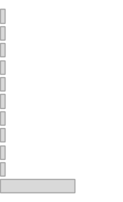

0  
(0.0%)

3

**flightDate**  
[object]

1. 2022-05-19  
2. 2022-05-24  
3. 2022-05-17  
4. 2022-05-18  
5. 2022-05-20  
6. 2022-05-25  
7. 2022-05-23  
8. 2022-05-21  
9. 2022-05-26  
10. 2022-05-16  
11. other

202,062 (2.1%)  
201,978 (2.1%)  
197,061 (2.1%)  
196,323 (2.1%)  
191,721 (2.0%)  
191,700 (2.0%)  
185,079 (2.0%)  
177,648 (1.9%)  
176,535 (1.9%)  
175,665 (1.9%)  
7,571,736 (80.0%)

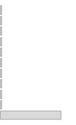

0  
(0.0%)

4

**startingAirport**  
[object]

1. SFO  
2. ORD  
3. PHL  
4. OAK

2,847,138 (30.1%)  
2,683,938 (28.3%)  
2,355,117 (24.9%)  
1,581,315 (16.7%)

0  
(0.0%)

5

**destinationAirport**  
[object]

1. LGA  
2. LAX  
3. DFW  
4. MIA  
5. ATL  
6. CLT  
7. BOS  
8. EWR  
9. DEN  
10. JFK  
11. other

948,063 (10.0%)  
796,320 (8.4%)  
725,808 (7.7%)  
707,577 (7.5%)  
681,567 (7.2%)  
670,254 (7.1%)  
667,050 (7.0%)  
629,814 (6.7%)  
568,365 (6.0%)  
561,432 (5.9%)  
2,511,258 (26.5%)

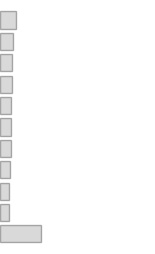

0  
(0.0%)

6

**travelDuration**  
[object]

1. PT2H4M  
2. PT2H5M  
3. PT2H18M  
4. PT5H45M  
5. PT5H42M  
6. PT5H46M  
7. PT2H1M  
8. PT2H16M  
9. PT4H35M  
10. PT5H51M  
11. other

52,581 (0.6%)  
42,276 (0.4%)  
41,211 (0.4%)  
36,324 (0.4%)  
33,528 (0.4%)  
32,097 (0.3%)  
30,891 (0.3%)  
29,289 (0.3%)  
29,013 (0.3%)  
28,542 (0.3%)  
9,111,756 (96.2%)

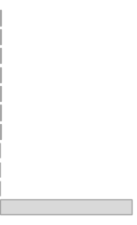

0  
(0.0%)

7

**isBasicEconomy**  
[bool]

1. False  
2. True

9,144,615 (96.6%)  
322,893 (3.4%)

0  
(0.0%)

8

**isRefundable**  
[bool]

1. False  
2. True

9,467,361 (100.0%)  
147 (0.0%)

0  
(0.0%)

9

**isNonStop**  
[bool]

1. False  
2. True

7,216,137 (76.2%)  
2,251,371 (23.8%)

0  
(0.0%)

10

**totalFare**  
[float64]

Mean (sd) : 432.9 (238.1)  
min < med < max:  
24.0 < 408.6 < 8260.6  
IQR (CV) : 309.0 (1.8)

22,601 distinct values

0  
(0.0%)

11

**totalTravelDistance**  
[float64]

Mean (sd) : 1778.7 (906.5)  
min < med < max:  
97.0 < 1784.0 < 4430.0  
IQR (CV) : 1663.0 (2.0)

1,897 distinct values

666,639  
(7.0%)

12

**segmentsDepartureTimeEpochSeconds**  
[object]

1. 1653138000  
2. 1653742800  
3. 1652965200  
4. 1652533200  
5. 1653397200  
6. 1653310800  
7. 1653224400  
8. 1652878800  
9. 1653829200  
10. 1653483600  
11. other

969 (0.0%)  
900 (0.0%)  
891 (0.0%)  
888 (0.0%)  
870 (0.0%)  
867 (0.0%)  
861 (0.0%)  
858 (0.0%)  
846 (0.0%)  
840 (0.0%)  
9,458,718 (99.9%)

0  
(0.0%)

13

**segmentsDepartureTimeRaw**  
[object]

1. 2022-05-19T06:00:00.000-07:00  
2. 2022-05-21T06:00:00.000-07:00  
3. 2022-05-24T06:00:00.000-07:00  
4. 2022-05-23T06:00:00.000-07:00  
5. 2022-05-22T06:00:00.000-07:00  
6. 2022-05-20T06:00:00.000-07:00  
7. 2022-05-18T06:00:00.000-07:00  
8. 2022-05-17T06:00:00.000-07:00  
9. 2022-05-25T06:00:00.000-07:00  
10. 2022-05-27T06:00:00.000-07:00  
11. other

801 (0.0%)  
789 (0.0%)  
783 (0.0%)  
780 (0.0%)  
774 (0.0%)  
774 (0.0%)  
771 (0.0%)  
756 (0.0%)  
756 (0.0%)  
753 (0.0%)  
9,459,771 (99.9%)

0  
(0.0%)

14

**segmentsArrivalTimeEpochSeconds**  
[object]

1. 1653044400  
2. 1653476400  
3. 1653390000  
4. 1653303600  
5. 1653735600  
6. 1653562800  
7. 1653649200  
8. 1653822000  
9. 1653994800  
10. 1653908400  
11. other

528 (0.0%)  
522 (0.0%)  
522 (0.0%)  
516 (0.0%)  
504 (0.0%)  
504 (0.0%)  
495 (0.0%)  
486 (0.0%)  
468 (0.0%)  
465 (0.0%)  
9,462,498 (99.9%)

0  
(0.0%)

15

**segmentsArrivalTimeRaw**  
[object]

1. 2022-05-20T07:00:00.000-04:00  
2. 2022-05-25T07:00:00.000-04:00  
3. 2022-05-24T07:00:00.000-04:00  
4. 2022-05-23T07:00:00.000-04:00  
5. 2022-05-28T07:00:00.000-04:00  
6. 2022-05-26T07:00:00.000-04:00  
7. 2022-05-27T07:00:00.000-04:00  
8. 2022-05-29T07:00:00.000-04:00  
9. 2022-05-31T07:00:00.000-04:00  
10. 2022-05-30T07:00:00.000-04:00  
11. other

528 (0.0%)  
522 (0.0%)  
522 (0.0%)  
516 (0.0%)  
504 (0.0%)  
504 (0.0%)  
495 (0.0%)  
486 (0.0%)  
468 (0.0%)  
465 (0.0%)  
9,462,498 (99.9%)

0  
(0.0%)

16

**segmentsArrivalAirportCode**  
[object]

1. BOS  
2. LAX  
3. LGA  
4. EWR  
5. JFK  
6. ATL  
7. DFW  
8. ORD||LGA  
9. DEN  
10. ORD  
11. other

281,052 (3.0%)  
268,305 (2.8%)  
208,998 (2.2%)  
185,712 (2.0%)  
181,503 (1.9%)  
166,965 (1.8%)  
149,061 (1.6%)  
140,628 (1.5%)  
132,192 (1.4%)  
117,264 (1.2%)  
7,635,828 (80.7%)

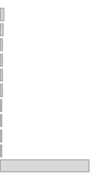

0  
(0.0%)

17

**segmentsDepartureAirportCode**  
[object]

1. ORD  
2. SFO  
3. PHL  
4. PHL||ORD  
5. OAK||LAX  
6. PHL||ATL  
7. PHL||BOS  
8. SFO||LAX  
9. SFO||JFK  
10. OAK||SEA  
11. other

1,102,260 (11.6%)  
700,323 (7.4%)  
413,355 (4.4%)  
335,205 (3.5%)  
262,500 (2.8%)  
257,916 (2.7%)  
221,565 (2.3%)  
190,713 (2.0%)  
188,634 (2.0%)  
187,326 (2.0%)  
5,607,711 (59.2%)

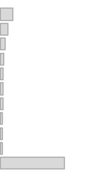

0  
(0.0%)

18

**segmentsAirlineName**  
[object]

1. American Airlines||American Ai  
2. Delta||Delta  
3. United||United  
4. American Airlines  
5. United  
6. Spirit Airlines||Spirit Airlin  
7. Alaska Airlines||Alaska Airlin  
8. JetBlue Airways||JetBlue Airwa  
9. Delta  
10. Delta||United||United  
11. other

1,374,645 (14.5%)  
1,364,928 (14.4%)  
998,922 (10.6%)  
825,753 (8.7%)  
670,254 (7.1%)  
521,571 (5.5%)  
394,176 (4.2%)  
347,496 (3.7%)  
293,454 (3.1%)  
282,171 (3.0%)  
2,394,138 (25.3%)

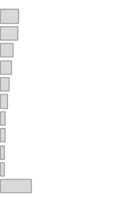

0  
(0.0%)

19

**segmentsAirlineCode**  
[object]

1. AA||AA  
2. DL||DL  
3. UA||UA  
4. AA  
5. UA  
6. NK||NK  
7. AS||AS  
8. B6||B6  
9. DL  
10. DL||UA||UA  
11. other

1,374,645 (14.5%)  
1,364,928 (14.4%)  
998,922 (10.6%)  
825,753 (8.7%)  
670,254 (7.1%)  
521,571 (5.5%)  
394,176 (4.2%)  
347,496 (3.7%)  
293,454 (3.1%)  
282,171 (3.0%)  
2,394,138 (25.3%)

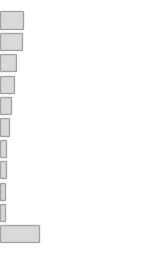

0  
(0.0%)

20

**segmentsEquipmentDescription**  
[object]

1. Boeing 737-800  
2. Airbus A321  
3. Boeing 737-800||Boeing 737-800  
4. Boeing 737-900  
5. Airbus A319  
6. Airbus A321||Airbus A321  
7. Airbus A320  
8. ||  
9. nan  
10. Airbus A321||Boeing 737-800  
11. other

429,234 (4.5%)  
265,191 (2.8%)  
250,404 (2.6%)  
232,413 (2.5%)  
176,904 (1.9%)  
174,861 (1.8%)  
168,039 (1.8%)  
164,262 (1.7%)  
158,610 (1.7%)  
152,643 (1.6%)  
7,294,947 (77.1%)

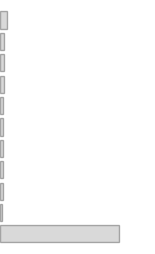

158,610  
(1.7%)

21

**segmentsDurationInSeconds**  
[object]

1. 7440  
2. 7500  
3. 8280  
4. 7260  
5. 8160  
6. 7380  
7. 8220  
8. 7620  
9. 20700  
10. 8640  
11. other

52,581 (0.6%)  
42,276 (0.4%)  
41,211 (0.4%)  
30,891 (0.3%)  
29,289 (0.3%)  
28,293 (0.3%)  
28,086 (0.3%)  
27,915 (0.3%)  
26,844 (0.3%)  
26,496 (0.3%)  
9,133,626 (96.5%)

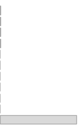

0  
(0.0%)

22

**segmentsDistance**  
[object]

1. None||None  
2. 720  
3. 2566  
4. 862  
5. 339  
6. 672||720  
7. 672  
8. 1847  
9. 280||185  
10. 594||221  
11. other

573,744 (6.1%)  
366,648 (3.9%)  
195,501 (2.1%)  
142,875 (1.5%)  
131,028 (1.4%)  
125,043 (1.3%)  
115,302 (1.2%)  
115,140 (1.2%)  
111,162 (1.2%)  
98,361 (1.0%)  
7,492,704 (79.1%)

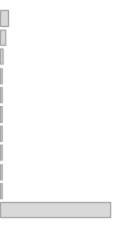

64,284  
(0.7%)

23

**segmentsCabinCode**  
[object]

1. coach||coach  
2. coach  
3. coach||coach||coach  
4. coach||coach||coach||coach  
5. first||coach  
6. premium coach  
7. first||first  
8. coach||premium coach  
9. coach||first  
10. premium coach||coach  
11. other

5,964,279 (63.0%)  
2,236,380 (23.6%)  
1,148,907 (12.1%)  
44,481 (0.5%)  
18,402 (0.2%)  
11,358 (0.1%)  
11,028 (0.1%)  
7,488 (0.1%)  
4,842 (0.1%)  
4,347 (0.0%)  
15,996 (0.2%)

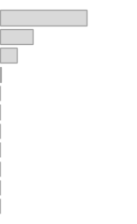

0  
(0.0%)

```python
dfSummary(df)
```

```python
# unique values for desitination airport
unique_airports = df['destinationAirport'].unique()
print(unique_airports)
```

```
['ATL' 'BOS' 'CLT' 'DEN' 'DFW' 'DTW' 'EWR' 'IAD' 'JFK' 'LAX' 'LGA' 'MIA'
 'ORD' 'PHL' 'SFO' 'OAK']
```

**At a quick glance here are the observations made:**

dimenstion: 9,467,508 x 23

1. There are 4 starting airport (SFO, ORD, PHL, OAK) since I am working on this subset
2. There are 16 destination airports.
3. Most of the tickets are not Basic Economy (96.6%)
4. Almost all the tickets are non refundable.
5. The median total fare is about 408.6 dollars with the highest being at 8260 dollars.
6. Median distance travelled is about 1784.0 miles with about 7% missing data.
7. If there are transits, the segments are broken down with || for some of the features stating Departure and Arrival Airport, Airline name, airline model, duration, distance and cabin code.
8. Data quality: there are 6,311,672 duplicate values

```python
print(df.dtypes)
```

```
legId                                 object
searchDate                            object
flightDate                            object
startingAirport                       object
destinationAirport                    object
travelDuration                        object
isBasicEconomy                          bool
isRefundable                            bool
isNonStop                               bool
totalFare                            float64
totalTravelDistance                  float64
segmentsDepartureTimeEpochSeconds     object
segmentsDepartureTimeRaw              object
segmentsArrivalTimeEpochSeconds       object
segmentsArrivalTimeRaw                object
segmentsArrivalAirportCode            object
segmentsDepartureAirportCode          object
segmentsAirlineName                   object
segmentsAirlineCode                   object
segmentsEquipmentDescription          object
segmentsDurationInSeconds             object
segmentsDistance                      object
segmentsCabinCode                     object
dtype: object
```

```python
#convert it to datetime
df['searchDate'] = pd.to_datetime(df['searchDate'], errors='coerce')

# Find the minimum and maximum dates
min_date = df['searchDate'].min()
max_date = df['searchDate'].max()

# Display the results
print(f"Minimum date: {min_date}")
print(f"Maximum date: {max_date}")
```

```
Minimum date: 2022-04-16 00:00:00
Maximum date: 2022-05-19 00:00:00
```

After converting the searchDate from object to Datetime, it is seen that the minimum date for searching a flight is on 16/4/2022 and the maximum date is 19/5/2022

```python
#convert it to datetime
df['flightDate'] = pd.to_datetime(df['flightDate'], errors='coerce')

# Find the minimum and maximum dates
min_date = df['flightDate'].min()
max_date = df['flightDate'].max()

# Display the results
print(f"Minimum date: {min_date}")
print(f"Maximum date: {max_date}")
```

```
Minimum date: 2022-04-17 00:00:00
Maximum date: 2022-07-17 00:00:00
```

After converting the flightDate from object to Datetime, it is seen that the minimum date for searching a flight is on 17/4/2022 and the maximum date is 17/7/2022. It means that some customers looked for flight on the next day from 16/4/2022.

```python
df_prep = df.copy()
```

The total duration is in ISO 8601 format and it will be converted to hours

```python
df_prep['travelDurationHours'] = df_prep['travelDuration'].apply(
    lambda x: isodate.parse_duration(x).total_seconds() / 3600
)
```

```python
df_prep.head()
```

|  | legId | searchDate | flightDate | startingAirport | destinationAirport | travelDuration | isBasicEconomy | isRefundable | isNonStop | totalFare | totalTravelDistance | segmentsDepartureTimeEpochSeconds | segmentsDepartureTimeRaw | segmentsArrivalTimeEpochSeconds | segmentsArrivalTimeRaw | segmentsArrivalAirportCode | segmentsDepartureAirportCode | segmentsAirlineName | segmentsAirlineCode | segmentsEquipmentDescription | segmentsDurationInSeconds | segmentsDistance | segmentsCabinCode | travelDurationHours |
| --- | --- | --- | --- | --- | --- | --- | --- | --- | --- | --- | --- | --- | --- | --- | --- | --- | --- | --- | --- | --- | --- | --- | --- | --- |
| 0 | 90be63bfc2848acb3a0d9a6c588b1f7d | 2022-04-16 | 2022-04-17 | OAK | ATL | PT6H32M | False | False | False | 307.60 | 2175.0 | 1650228600\|\|1650239400 | 2022-04-17T13:50:00.000-07:00\|\|2022-04-17T17:5... | 1650234660\|\|1650252120 | 2022-04-17T16:31:00.000-06:00\|\|2022-04-17T23:2... | SLC\|\|ATL | OAK\|\|SLC | Delta\|\|Delta | DL\|\|DL | \|\|Airbus A321 | 6060\|\|12720 | 588\|\|1587 | coach\|\|coach | 6.533333 |
| 1 | 2a6f46df8129bcab9b7fe6825b2e9431 | 2022-04-16 | 2022-04-17 | OAK | ATL | PT7H38M | False | False | False | 387.60 | 2281.0 | 1650204600\|\|1650216900 | 2022-04-17T07:10:00.000-07:00\|\|2022-04-17T10:3... | 1650209700\|\|1650232080 | 2022-04-17T08:35:00.000-07:00\|\|2022-04-17T17:4... | LAX\|\|ATL | OAK\|\|LAX | Delta\|\|Delta | DL\|\|DL | Embraer 175 (Enhanced Winglets)\|\|Airbus A321 | 5100\|\|15180 | 338\|\|1943 | coach\|\|coach | 7.633333 |
| 2 | 7bbf383c6e0433cfa4981efa7e5f459e | 2022-04-16 | 2022-04-17 | OAK | ATL | PT8H45M | True | False | False | 387.60 | 2850.0 | 1650202200\|\|1650216600 | 2022-04-17T06:30:00.000-07:00\|\|2022-04-17T10:3... | 1650209700\|\|1650233700 | 2022-04-17T08:35:00.000-07:00\|\|2022-04-17T18:1... | SEA\|\|ATL | OAK\|\|SEA | Alaska Airlines\|\|Alaska Airlines | AS\|\|AS | Airbus A320\|\|Boeing 737-900 | 7500\|\|17100 | 672\|\|2178 | coach\|\|coach | 8.750000 |
| 3 | beb2015506ff7697a4af6af599bb07ff | 2022-04-16 | 2022-04-17 | OAK | ATL | PT14H17M | False | False | False | 451.58 | NaN | 1650204600\|\|1650241200 | 2022-04-17T07:10:00.000-07:00\|\|2022-04-17T17:2... | 1650209640\|\|1650256020 | 2022-04-17T08:34:00.000-07:00\|\|2022-04-18T00:2... | LAX\|\|ATL | OAK\|\|LAX | Spirit Airlines\|\|Spirit Airlines | NK\|\|NK | \|\|AIRBUS INDUSTRIE A320 SHARKLETS | 5040\|\|14820 | None\|\|None | coach\|\|coach | 14.283333 |
| 4 | c5bfe3fb92bb262b94628a930fa30cef | 2022-04-16 | 2022-04-17 | OAK | ATL | PT9H6M | False | False | False | 463.58 | NaN | 1650239100\|\|1650258600 | 2022-04-17T16:45:00.000-07:00\|\|2022-04-17T22:1... | 1650244200\|\|1650271860 | 2022-04-17T18:10:00.000-07:00\|\|2022-04-18T04:5... | LAS\|\|ATL | OAK\|\|LAS | Spirit Airlines\|\|Spirit Airlines | NK\|\|NK | \|\|AIRBUS INDUSTRIE A320 SHARKLETS | 5100\|\|13260 | None\|\|None | coach\|\|coach | 9.100000 |

```python
pd.options.display.float_format = '{:.2f}'.format
df_prep['travelDurationHours'].describe()
```

```
count   9467508.00
mean          7.74
std           3.94
min           0.77
25%           4.87
50%           7.52
75%          10.30
max          39.53
Name: travelDurationHours, dtype: float64
```

Based on this new feature, we can see that the median value for the flight duration is about 7.5 hours, minimum value is less than an hour and max is about 39.5 hours

### duplicate handling

```python
# Count the total number of duplicate rows
total_duplicates = df_prep.duplicated().sum()

# Display the total count
print(f"Total number of duplicate rows: {total_duplicates}")
```

```
Total number of duplicate rows: 6311672
```

```python
#let's verify if all the columns match in some of the duplicates

# Find all duplicate rows (including the first occurrence)
duplicates = df_prep[df_prep.duplicated(keep=False)]

# Sort the duplicates to group identical rows together
grouped_duplicates = duplicates.sort_values(list(df_prep.columns))

# Display the grouped duplicate observations
grouped_duplicates.head()
```

|  | legId | searchDate | flightDate | startingAirport | destinationAirport | travelDuration | isBasicEconomy | isRefundable | isNonStop | totalFare | totalTravelDistance | segmentsDepartureTimeEpochSeconds | segmentsDepartureTimeRaw | segmentsArrivalTimeEpochSeconds | segmentsArrivalTimeRaw | segmentsArrivalAirportCode | segmentsDepartureAirportCode | segmentsAirlineName | segmentsAirlineCode | segmentsEquipmentDescription | segmentsDurationInSeconds | segmentsDistance | segmentsCabinCode | travelDurationHours |
| --- | --- | --- | --- | --- | --- | --- | --- | --- | --- | --- | --- | --- | --- | --- | --- | --- | --- | --- | --- | --- | --- | --- | --- | --- |
| 689362 | 00002b928c8609d1d06bad965f2e80f5 | 2022-04-21 | 2022-06-12 | ORD | IAD | PT7H17M | False | False | False | 493.60 | 941.00 | 1655062020\|\|1655082300 | 2022-06-12T14:27:00.000-05:00\|\|2022-06-12T21:0... | 1655071200\|\|1655088240 | 2022-06-12T18:00:00.000-04:00\|\|2022-06-12T22:4... | JFK\|\|IAD | ORD\|\|JFK | Delta\|\|Delta | DL\|\|DL | Canadair Regional Jet 900\|\|Embraer 175 | 9180\|\|5940 | 720\|\|221 | coach\|\|coach | 7.28 |
| 3845198 | 00002b928c8609d1d06bad965f2e80f5 | 2022-04-21 | 2022-06-12 | ORD | IAD | PT7H17M | False | False | False | 493.60 | 941.00 | 1655062020\|\|1655082300 | 2022-06-12T14:27:00.000-05:00\|\|2022-06-12T21:0... | 1655071200\|\|1655088240 | 2022-06-12T18:00:00.000-04:00\|\|2022-06-12T22:4... | JFK\|\|IAD | ORD\|\|JFK | Delta\|\|Delta | DL\|\|DL | Canadair Regional Jet 900\|\|Embraer 175 | 9180\|\|5940 | 720\|\|221 | coach\|\|coach | 7.28 |
| 7001034 | 00002b928c8609d1d06bad965f2e80f5 | 2022-04-21 | 2022-06-12 | ORD | IAD | PT7H17M | False | False | False | 493.60 | 941.00 | 1655062020\|\|1655082300 | 2022-06-12T14:27:00.000-05:00\|\|2022-06-12T21:0... | 1655071200\|\|1655088240 | 2022-06-12T18:00:00.000-04:00\|\|2022-06-12T22:4... | JFK\|\|IAD | ORD\|\|JFK | Delta\|\|Delta | DL\|\|DL | Canadair Regional Jet 900\|\|Embraer 175 | 9180\|\|5940 | 720\|\|221 | coach\|\|coach | 7.28 |
| 1152221 | 0000f1fce0aea001c0de9ee1dc630cd8 | 2022-05-06 | 2022-05-15 | ORD | SFO | PT8H26M | False | False | False | 891.60 | 2402.00 | 1652645520\|\|1652668200 | 2022-05-15T15:12:00.000-05:00\|\|2022-05-15T19:3... | 1652661840\|\|1652675880 | 2022-05-15T17:44:00.000-07:00\|\|2022-05-15T21:3... | SEA\|\|SFO | ORD\|\|SEA | Alaska Airlines\|\|United | AS\|\|UA | Boeing 737-800\|\|Airbus A319 | 16320\|\|7680 | 1723\|\|679 | coach\|\|coach | 8.43 |
| 4308057 | 0000f1fce0aea001c0de9ee1dc630cd8 | 2022-05-06 | 2022-05-15 | ORD | SFO | PT8H26M | False | False | False | 891.60 | 2402.00 | 1652645520\|\|1652668200 | 2022-05-15T15:12:00.000-05:00\|\|2022-05-15T19:3... | 1652661840\|\|1652675880 | 2022-05-15T17:44:00.000-07:00\|\|2022-05-15T21:3... | SEA\|\|SFO | ORD\|\|SEA | Alaska Airlines\|\|United | AS\|\|UA | Boeing 737-800\|\|Airbus A319 | 16320\|\|7680 | 1723\|\|679 | coach\|\|coach | 8.43 |

```python
grouped_duplicates.tail()
```

|  | legId | searchDate | flightDate | startingAirport | destinationAirport | travelDuration | isBasicEconomy | isRefundable | isNonStop | totalFare | totalTravelDistance | segmentsDepartureTimeEpochSeconds | segmentsDepartureTimeRaw | segmentsArrivalTimeEpochSeconds | segmentsArrivalTimeRaw | segmentsArrivalAirportCode | segmentsDepartureAirportCode | segmentsAirlineName | segmentsAirlineCode | segmentsEquipmentDescription | segmentsDurationInSeconds | segmentsDistance | segmentsCabinCode | travelDurationHours |
| --- | --- | --- | --- | --- | --- | --- | --- | --- | --- | --- | --- | --- | --- | --- | --- | --- | --- | --- | --- | --- | --- | --- | --- | --- |
| 5347436 | ffffc8454a7d7c6ec22d0c1a09e03134 | 2022-05-18 | 2022-07-03 | PHL | OAK | PT11H45M | False | False | False | 607.21 | 2519.00 | 1656867600\|\|1656891900 | 2022-07-03T13:00:00.000-04:00\|\|2022-07-03T19:4... | 1656873900\|\|1656909900 | 2022-07-03T14:45:00.000-04:00\|\|2022-07-03T21:4... | DTW\|\|OAK | PHL\|\|DTW | Delta\|\|Delta | DL\|\|DL | Canadair Regional Jet 900\|\|Boeing 737-900 | 6300\|\|18000 | 447\|\|2072 | coach\|\|coach | 11.75 |
| 8503272 | ffffc8454a7d7c6ec22d0c1a09e03134 | 2022-05-18 | 2022-07-03 | PHL | OAK | PT11H45M | False | False | False | 607.21 | 2519.00 | 1656867600\|\|1656891900 | 2022-07-03T13:00:00.000-04:00\|\|2022-07-03T19:4... | 1656873900\|\|1656909900 | 2022-07-03T14:45:00.000-04:00\|\|2022-07-03T21:4... | DTW\|\|OAK | PHL\|\|DTW | Delta\|\|Delta | DL\|\|DL | Canadair Regional Jet 900\|\|Boeing 737-900 | 6300\|\|18000 | 447\|\|2072 | coach\|\|coach | 11.75 |
| 2289063 | ffffe7aa2c35e8bf4d567cc544ce006d | 2022-04-19 | 2022-05-04 | SFO | LGA | PT12H35M | False | False | False | 356.09 | 2808.00 | 1651669200\|\|1651687440\|\|1651701000 | 2022-05-04T06:00:00.000-07:00\|\|2022-05-04T11:0... | 1651675620\|\|1651695840\|\|1651714500 | 2022-05-04T07:47:00.000-07:00\|\|2022-05-04T14:2... | LAX\|\|DEN\|\|LGA | SFO\|\|LAX\|\|DEN | United\|\|United\|\|United | UA\|\|UA\|\|UA | Airbus A320\|\|Boeing 737-900\|\|Airbus A319 | 6420\|\|8400\|\|13500 | 339\|\|848\|\|1621 | coach\|\|coach\|\|coach | 12.58 |
| 5444899 | ffffe7aa2c35e8bf4d567cc544ce006d | 2022-04-19 | 2022-05-04 | SFO | LGA | PT12H35M | False | False | False | 356.09 | 2808.00 | 1651669200\|\|1651687440\|\|1651701000 | 2022-05-04T06:00:00.000-07:00\|\|2022-05-04T11:0... | 1651675620\|\|1651695840\|\|1651714500 | 2022-05-04T07:47:00.000-07:00\|\|2022-05-04T14:2... | LAX\|\|DEN\|\|LGA | SFO\|\|LAX\|\|DEN | United\|\|United\|\|United | UA\|\|UA\|\|UA | Airbus A320\|\|Boeing 737-900\|\|Airbus A319 | 6420\|\|8400\|\|13500 | 339\|\|848\|\|1621 | coach\|\|coach\|\|coach | 12.58 |
| 8600735 | ffffe7aa2c35e8bf4d567cc544ce006d | 2022-04-19 | 2022-05-04 | SFO | LGA | PT12H35M | False | False | False | 356.09 | 2808.00 | 1651669200\|\|1651687440\|\|1651701000 | 2022-05-04T06:00:00.000-07:00\|\|2022-05-04T11:0... | 1651675620\|\|1651695840\|\|1651714500 | 2022-05-04T07:47:00.000-07:00\|\|2022-05-04T14:2... | LAX\|\|DEN\|\|LGA | SFO\|\|LAX\|\|DEN | United\|\|United\|\|United | UA\|\|UA\|\|UA | Airbus A320\|\|Boeing 737-900\|\|Airbus A319 | 6420\|\|8400\|\|13500 | 339\|\|848\|\|1621 | coach\|\|coach\|\|coach | 12.58 |

Therefore we can conclude that there are actually duplicate observations and it's a significant number. 6,311,672/9,467,508 are duplicates which is 2/3 of the dataset.

```python
#dropping duplicates
df_prep = df_prep.drop_duplicates()
```

```python
# Count the total number of duplicate rows
total_duplicates = df_prep.duplicated().sum()

# Display the total count
print(f"Total number of duplicate rows: {total_duplicates}")
```

```
Total number of duplicate rows: 0
```

```python
df_prep.shape
```

```
(3155836, 24)
```

It can be seen that the dataframe is now 1/3 of the initial size.

### Data Visualisation

##### Let's look at the distribution of the target variable

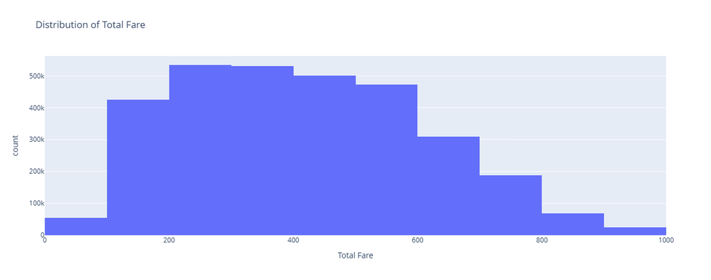

```python
fig = px.histogram(
    df_prep,
    x='totalFare',
    nbins=100,
    title='Distribution of Total Fare',
    labels={'totalFare': 'Total Fare'},
    width=800,
    height=500
)

# Limit the x-axis range to focus on the bulk of the data
fig.update_layout(xaxis=dict(range=[0, 1000]))

fig.show()
```

From the range and spread above, we can see that the totalFare values mainly fall bewteen 0 and 1000 dollars. The histogram is slighly right skewed and indicating that most fares are concentrated between 200 and 600. As fare amount increases, the frequency decreases.

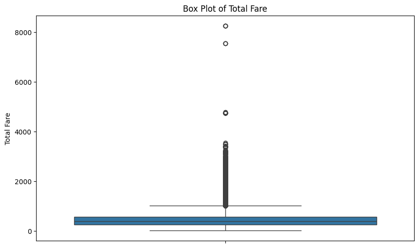

```python
import matplotlib.pyplot as plt
import seaborn as sns

plt.figure(figsize=(10, 6))

# Create the box plot
sns.boxplot(y=df_prep['totalFare'])
plt.title('Box Plot of Total Fare')
plt.ylabel('Total Fare')

# Show the plot
plt.show()
```

From the box plot, we can see that the median fare is at the lower end (408). There are several datapoints which are beyond the upper whisker that go beyond 2000 dollars with some reaching as high as 8000 dollars.

```python
# Calculate Q1 (25th percentile) and Q3 (75th percentile)
Q1 = df_prep['totalFare'].quantile(0.25)
Q3 = df_prep['totalFare'].quantile(0.75)

# Calculate the Interquartile Range (IQR)
IQR = Q3 - Q1

# Define the upper and lower bounds for outliers
lower_bound = Q1 - 1.5 * IQR
upper_bound = Q3 + 1.5 * IQR

# Identify outliers
outliers = df_prep[(df_prep['totalFare'] < lower_bound) | (df_prep['totalFare'] > upper_bound)]

# Count the number of outliers
outlier_count = outliers.shape[0]

# Display the result
print(f"Number of outliers in totalFare: {outlier_count}")
```

```
Number of outliers in totalFare: 42850
```

We can see that there are about 42,850 rows which are outliers (1.35% of data). Since my objective is to predict typical fares, I will remove the outliers.

```python
#REMOVE OUTLIERS
# Calculate Q1 (25th percentile) and Q3 (75th percentile)
Q1 = df_prep['totalFare'].quantile(0.25)
Q3 = df_prep['totalFare'].quantile(0.75)

# Calculate the Interquartile Range (IQR)
IQR = Q3 - Q1

# Define the upper and lower bounds for outliers
lower_bound = Q1 - 1.5 * IQR
upper_bound = Q3 + 1.5 * IQR

# Remove outliers from the DataFrame
df_prep = df_prep[(df_prep['totalFare'] >= lower_bound) & (df_prep['totalFare'] <= upper_bound)]

# Verify the new size of the DataFrame
print(f"Number of rows after removing outliers: {df_prep.shape[0]}")
```

```
Number of rows after removing outliers: 3112986
```

##### Let's look at the frequency of starting and destination airports

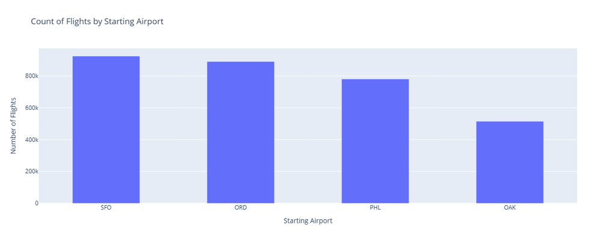

```python
#  Count occurrences of each starting airport
airport_counts = df_prep['startingAirport'].value_counts().reset_index()
airport_counts.columns = ['startingAirport', 'Count']

# Create the bar chart
fig = px.bar(
    airport_counts,
    x='startingAirport',
    y='Count',
    title='Count of Flights by Starting Airport',
    labels={'startingAirport': 'Starting Airport', 'Count': 'Number of Flights'},
    width=600,
    height=500
)

fig.update_traces(width=0.5)

# Plot
fig.show()
```

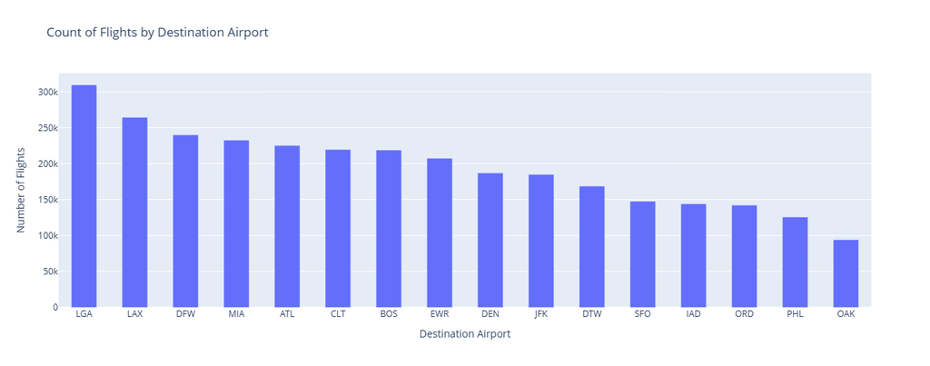

```python
# Count occurrences of each destination airport
airport_counts = df_prep['destinationAirport'].value_counts().reset_index()
airport_counts.columns = ['destinationAirport', 'Count']

# Create the bar chart
fig = px.bar(
    airport_counts,
    x='destinationAirport',
    y='Count',
    title='Count of Flights by Destination Airport',
    labels={'destinationAirport': 'Destination Airport', 'Count': 'Number of Flights'},
    width=600,
    height=500
)


fig.update_traces(width=0.5)

# Plot
fig.show()
```

We can see that the highest frequency of flights took off from SFO and the least from OAK. The highest frequency destination airport was LGA and the least was OAK.

##### Distribution of total travel distance

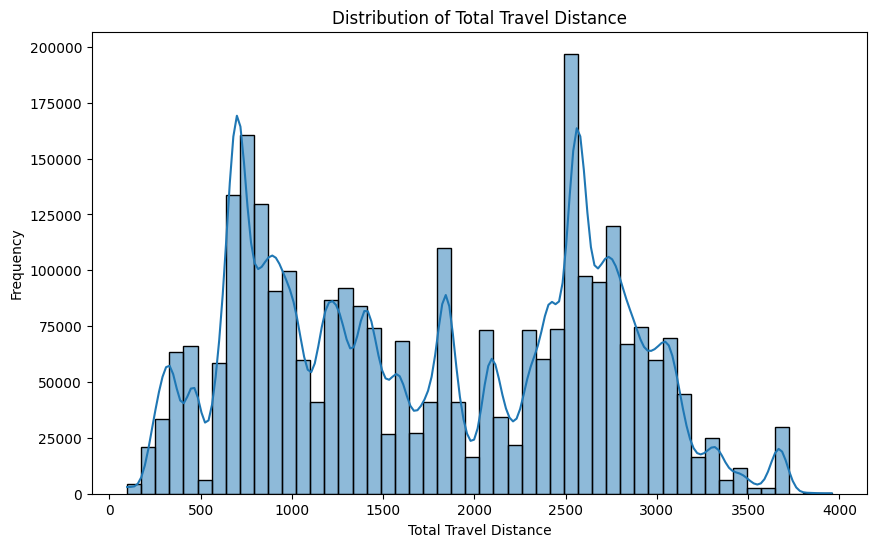

```python
import matplotlib.pyplot as plt
import seaborn as sns

# Step 1: Set plot size
plt.figure(figsize=(10, 6))

# Step 2: Create a histogram using Seaborn
sns.histplot(df_prep['totalTravelDistance'], bins=50, kde=True)

# Step 3: Add title and labels
plt.title('Distribution of Total Travel Distance')
plt.xlabel('Total Travel Distance')
plt.ylabel('Frequency')

# Step 4: Show the plot
plt.show()
```

```python
# Extract the first segment (before the first '|') from 'segmentsCabinCode'
df_prep['firstSegmentCabinCode'] = df_prep['segmentsCabinCode'].str.split('|').str[0]

# Count the frequency of the first segments
first_segment_counts = df_prep['firstSegmentCabinCode'].value_counts()

# Display the frequency
print(first_segment_counts)
```

```
firstSegmentCabinCode
coach            3107569
premium coach       3292
first               1888
business             237
Name: count, dtype: int64
```

We can see that majority of the observations have coach as the cabin code for the first segment of the flight.

```python
#Extract the first airline name (before the first '|') from 'segmentsAirlineName'
df_prep['firstSegmentAirline'] = df_prep['segmentsAirlineName'].str.split('|').str[0]

# Count the frequency of the first airline names
first_airline_counts = df_prep['firstSegmentAirline'].value_counts()

# Display the frequency
print(first_airline_counts)
```

```
firstSegmentAirline
Delta                   779160
American Airlines       761289
United                  710976
Alaska Airlines         372961
Spirit Airlines         201732
JetBlue Airways         199752
Frontier Airlines        65972
Cape Air                 11005
Sun Country Airlines      8943
Key Lime Air              1180
Hawaiian Airlines           16
Name: count, dtype: int64
```

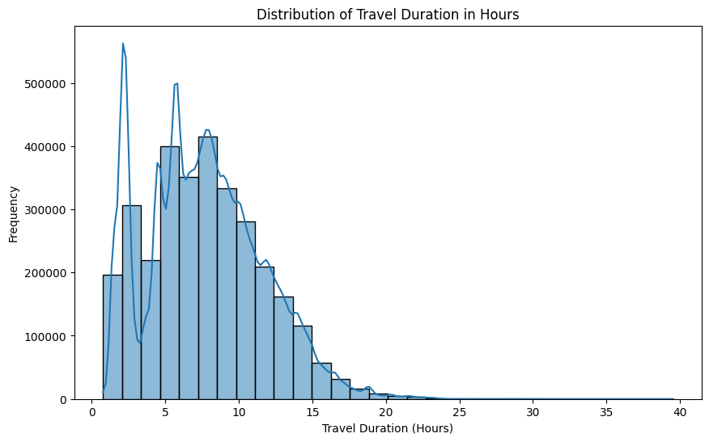

```python
# Set plot size
plt.figure(figsize=(10, 6))

# Create a histogram with KDE overlay
sns.histplot(df_prep['travelDurationHours'], bins=30, kde=True)

# Add title and labels
plt.title('Distribution of Travel Duration in Hours')
plt.xlabel('Travel Duration (Hours)')
plt.ylabel('Frequency')

# Show the plot
plt.show()
```

From the chart above, we can see that majority of the flights have a shorter travel duration (2-10 hours) with a decreasing number of longer flights. There are some flights that extend up to 40 hours but very rate.

```python
#save to interim folder
file_path = 'E:/OneDrive - UTS/Sem 4 (Spring 2024)/Advanced ML Applications/Assignment 3/adv_mla_at3/data/interim/df_airport_farhan_faiyaz.csv'
df_prep.to_csv(file_path, index=False)
```